# Mini Project 1

Doney Zhang • 9 Sept Due 7 Oct Description:

The purpose of the Mini Project is to reinforce skills that have been covered in recent modules.

Choose a business problem and translate it into a data science problem. Select a data set and analyse it using the techniques learned in recent modules. The techniques include (but not limited to) the following: Data Wrangling, Feature Engineering, EDA..

Prepare and present a 10 min in Jupyter Notebook for technical discussion with business insights in class.

## Presentation to be held on 7th Oct.

Rubric:

- Explanation of the business context behind the dataset
- Quality of presentation - engaging, well structured, not too short or too long
- Quality of the notebook - code well documented, runs correctly
- Time-management - please keep strictly to the time given

Marking

1. Code tidiness - 2
2. EDA process - 3
3. Insights - 3
4. paticipations - 1 (asking questions)
5. topic - 1
6. Bonus - 2 (try difficult)

Solar Capacity Growing in Denmark & France

Agenda: To determine the better country to invest Solar for the best value of the Company

Sourse: https://data.open-power-system-data.org/renewable_power_plants/

1. Import the necessary libraries

```python
import pandas as pd
import numpy as np
import matplotlib.pyplot as plt
import seaborn as sns
# It is good practice to display the library version numbers for future reference:
print('Numpy: ', np.__version__)
print('Pandas: ', pd.__version__)
```

```
Numpy:  1.24.3
Pandas:  1.5.3
```

1. Load the file

```python
df = pd.read_csv(r'C:\Users\brucx\Downloads\Data Science\Mini Project 1\Data_Mini Project 1\EU_renewable_capacity_timeseries.csv')
```

1. Explore the dataset by checking its structure and basic statistics:

```python
# Display the first few rows of the DataFrame
df.head()
```

|  | day | CH_bioenergy_capacity | CH_solar_capacity | CH_wind_onshore_capacity | DE_bioenergy_capacity | DE_geothermal_capacity | DE_solar_capacity | DE_wind_capacity | DE_wind_offshore_capacity | DE_wind_onshore_capacity | ... | GB-UKM_bioenergy_capacity | GB-UKM_hydro_capacity | GB-UKM_marine_capacity | GB-UKM_solar_capacity | GB-UKM_wind_capacity | GB-UKM_wind_offshore_capacity | GB-UKM_wind_onshore_capacity | SE_wind_capacity | SE_wind_offshore_capacity | SE_wind_onshore_capacity |
| --- | --- | --- | --- | --- | --- | --- | --- | --- | --- | --- | --- | --- | --- | --- | --- | --- | --- | --- | --- | --- | --- |
| 0 | 1900-01-01 | 0.0 | 0.0 | 0.0 | 0.00 | 0.0 | 0.0 | 0.0 | 0.0 | 0.0 | ... | 0.0 | 0.0 | 0.0 | 0.0 | 0.0 | 0.0 | 0.0 | 0.0 | 0.0 | 0.0 |
| 1 | 1900-01-02 | 0.0 | 0.0 | 0.0 | 0.08 | 0.0 | 0.0 | 0.0 | 0.0 | 0.0 | ... | 0.0 | 0.0 | 0.0 | 0.0 | 0.0 | 0.0 | 0.0 | 0.0 | 0.0 | 0.0 |
| 2 | 1900-01-03 | 0.0 | 0.0 | 0.0 | 0.08 | 0.0 | 0.0 | 0.0 | 0.0 | 0.0 | ... | 0.0 | 0.0 | 0.0 | 0.0 | 0.0 | 0.0 | 0.0 | 0.0 | 0.0 | 0.0 |
| 3 | 1900-01-04 | 0.0 | 0.0 | 0.0 | 0.08 | 0.0 | 0.0 | 0.0 | 0.0 | 0.0 | ... | 0.0 | 0.0 | 0.0 | 0.0 | 0.0 | 0.0 | 0.0 | 0.0 | 0.0 | 0.0 |
| 4 | 1900-01-05 | 0.0 | 0.0 | 0.0 | 0.08 | 0.0 | 0.0 | 0.0 | 0.0 | 0.0 | ... | 0.0 | 0.0 | 0.0 | 0.0 | 0.0 | 0.0 | 0.0 | 0.0 | 0.0 | 0.0 |

5 rows × 40 columns

```python
# Display the last few rows of the DataFrame
df.tail()
```

|  | day | CH_bioenergy_capacity | CH_solar_capacity | CH_wind_onshore_capacity | DE_bioenergy_capacity | DE_geothermal_capacity | DE_solar_capacity | DE_wind_capacity | DE_wind_offshore_capacity | DE_wind_onshore_capacity | ... | GB-UKM_bioenergy_capacity | GB-UKM_hydro_capacity | GB-UKM_marine_capacity | GB-UKM_solar_capacity | GB-UKM_wind_capacity | GB-UKM_wind_offshore_capacity | GB-UKM_wind_onshore_capacity | SE_wind_capacity | SE_wind_offshore_capacity | SE_wind_onshore_capacity |
| --- | --- | --- | --- | --- | --- | --- | --- | --- | --- | --- | --- | --- | --- | --- | --- | --- | --- | --- | --- | --- | --- |
| 44161 | 2020-11-28 | 87.165 | 620.399 | 64.173 | 8021.331 | 51.094 | 50508.38 | 50451.642 | 5741.634 | 44710.008 | ... | 6737.7 | 3442.6 | 34.5 | 8468.3 | 23020.0 | 9692.7 | 13327.3 | 9514.16 | 191.15 | 9323.01 |
| 44162 | 2020-11-29 | 87.165 | 620.399 | 64.173 | 8021.331 | 51.094 | 50508.38 | 50451.642 | 5741.634 | 44710.008 | ... | 6737.7 | 3442.6 | 34.5 | 8468.3 | 23020.0 | 9692.7 | 13327.3 | 9514.16 | 191.15 | 9323.01 |
| 44163 | 2020-11-30 | 87.165 | 620.399 | 64.173 | 8021.331 | 51.094 | 50508.38 | 50451.642 | 5741.634 | 44710.008 | ... | 6737.7 | 3442.6 | 34.5 | 8468.3 | 23020.0 | 9692.7 | 13327.3 | 9514.16 | 191.15 | 9323.01 |
| 44164 | 2020-12-01 | 87.165 | 620.399 | 64.173 | 8021.331 | 51.094 | 50508.38 | 50451.642 | 5741.634 | 44710.008 | ... | 6737.7 | 3442.6 | 34.5 | 8468.3 | 23020.0 | 9692.7 | 13327.3 | 9514.16 | 191.15 | 9323.01 |
| 44165 | 2020-12-02 | 87.165 | 620.399 | 64.173 | 8021.331 | 51.094 | 50508.38 | 50451.642 | 5741.634 | 44710.008 | ... | 6737.7 | 3442.6 | 34.5 | 8473.3 | 23020.0 | 9692.7 | 13327.3 | 9514.16 | 191.15 | 9323.01 |

5 rows × 40 columns

```python
# Display the number of rows and columns in the DataFrame
rows = len(df.axes[0])
columns = len(df.axes[1])
print("Rows: ", rows)
print("Columns: ", columns)
```

```
Rows:  44166
Columns:  40
```

```python
# Display the column names
df.columns
```

```
Index(['day', 'CH_bioenergy_capacity', 'CH_solar_capacity',
       'CH_wind_onshore_capacity', 'DE_bioenergy_capacity',
       'DE_geothermal_capacity', 'DE_solar_capacity', 'DE_wind_capacity',
       'DE_wind_offshore_capacity', 'DE_wind_onshore_capacity',
       'DK_solar_capacity', 'DK_wind_capacity', 'DK_wind_offshore_capacity',
       'DK_wind_onshore_capacity', 'FR_bioenergy_capacity',
       'FR_geothermal_capacity', 'FR_hydro_capacity', 'FR_marine_capacity',
       'FR_solar_capacity', 'FR_wind_onshore_capacity',
       'GB-GBN_bioenergy_capacity', 'GB-GBN_hydro_capacity',
       'GB-GBN_marine_capacity', 'GB-GBN_solar_capacity',
       'GB-GBN_wind_capacity', 'GB-GBN_wind_offshore_capacity',
       'GB-GBN_wind_onshore_capacity', 'GB-NIR_bioenergy_capacity',
       'GB-NIR_solar_capacity', 'GB-NIR_wind_onshore_capacity',
       'GB-UKM_bioenergy_capacity', 'GB-UKM_hydro_capacity',
       'GB-UKM_marine_capacity', 'GB-UKM_solar_capacity',
       'GB-UKM_wind_capacity', 'GB-UKM_wind_offshore_capacity',
       'GB-UKM_wind_onshore_capacity', 'SE_wind_capacity',
       'SE_wind_offshore_capacity', 'SE_wind_onshore_capacity'],
      dtype='object')
```

3.1. Reformat Dataframe

```python
from datetime import datetime

# Convert the 'day' column to datetime format
df['day'] = pd.to_datetime(df['day'])

# Convert the datetime format to year-month-day format
df['day'] = df['day'].dt.strftime('%Y-%m-%d')
```

```python
df['day'] = pd.to_datetime(df['day'])

# Select all rows with a date year-12-31
df_y = df.loc[(df['day'].dt.month == 12) & (df['day'].dt.day == 31)]

# Print the selected rows
df_y
```

|  | day | CH_bioenergy_capacity | CH_solar_capacity | CH_wind_onshore_capacity | DE_bioenergy_capacity | DE_geothermal_capacity | DE_solar_capacity | DE_wind_capacity | DE_wind_offshore_capacity | DE_wind_onshore_capacity | ... | GB-UKM_bioenergy_capacity | GB-UKM_hydro_capacity | GB-UKM_marine_capacity | GB-UKM_solar_capacity | GB-UKM_wind_capacity | GB-UKM_wind_offshore_capacity | GB-UKM_wind_onshore_capacity | SE_wind_capacity | SE_wind_offshore_capacity | SE_wind_onshore_capacity |
| --- | --- | --- | --- | --- | --- | --- | --- | --- | --- | --- | --- | --- | --- | --- | --- | --- | --- | --- | --- | --- | --- |
| 364 | 1900-12-31 | 0.000 | 0.000 | 0.000 | 0.080 | 0.000 | 0.000 | 0.000 | 0.000 | 0.000 | ... | 0.0 | 0.0 | 0.0 | 0.0 | 0.0 | 0.0 | 0.0 | 0.00 | 0.00 | 0.00 |
| 729 | 1901-12-31 | 0.000 | 0.000 | 0.000 | 0.080 | 0.000 | 0.000 | 0.000 | 0.000 | 0.000 | ... | 0.0 | 0.0 | 0.0 | 0.0 | 0.0 | 0.0 | 0.0 | 0.00 | 0.00 | 0.00 |
| 1094 | 1902-12-31 | 0.000 | 0.000 | 0.000 | 0.080 | 0.000 | 0.000 | 0.000 | 0.000 | 0.000 | ... | 0.0 | 0.0 | 0.0 | 0.0 | 0.0 | 0.0 | 0.0 | 0.00 | 0.00 | 0.00 |
| 1459 | 1903-12-31 | 0.000 | 0.000 | 0.000 | 0.080 | 0.000 | 0.000 | 0.000 | 0.000 | 0.000 | ... | 0.0 | 0.0 | 0.0 | 0.0 | 0.0 | 0.0 | 0.0 | 0.00 | 0.00 | 0.00 |
| 1825 | 1904-12-31 | 0.000 | 0.000 | 0.000 | 0.080 | 0.000 | 0.000 | 0.000 | 0.000 | 0.000 | ... | 0.0 | 0.0 | 0.0 | 0.0 | 0.0 | 0.0 | 0.0 | 0.00 | 0.00 | 0.00 |
| ... | ... | ... | ... | ... | ... | ... | ... | ... | ... | ... | ... | ... | ... | ... | ... | ... | ... | ... | ... | ... | ... |
| 42367 | 2015-12-31 | 78.548 | 546.988 | 43.830 | 7907.526 | 32.030 | 38630.461 | 32812.120 | 2162.430 | 30649.690 | ... | 3964.9 | 3401.2 | 24.0 | 5637.4 | 13863.6 | 5094.0 | 8769.6 | 5758.87 | 191.15 | 5567.72 |
| 42733 | 2016-12-31 | 83.663 | 605.573 | 64.173 | 7934.303 | 37.530 | 40085.475 | 37144.815 | 2587.254 | 34557.561 | ... | 4266.5 | 3419.0 | 24.0 | 7520.0 | 15184.7 | 5094.0 | 10090.7 | 6366.55 | 191.15 | 6175.40 |
| 43098 | 2017-12-31 | 84.253 | 619.423 | 64.173 | 7950.886 | 37.530 | 41717.018 | 42862.566 | 3482.654 | 39379.912 | ... | 5260.5 | 3442.6 | 32.0 | 8307.5 | 18655.9 | 6512.0 | 12143.9 | 6532.85 | 191.15 | 6341.70 |
| 43463 | 2018-12-31 | 87.165 | 620.399 | 64.173 | 8001.808 | 45.594 | 47462.558 | 48974.171 | 5050.754 | 43923.417 | ... | 6518.7 | 3442.6 | 32.0 | 8407.0 | 20925.6 | 7904.7 | 13020.9 | 7383.95 | 191.15 | 7192.80 |
| 43828 | 2019-12-31 | 87.165 | 620.399 | 64.173 | 8021.331 | 51.094 | 50508.380 | 50451.642 | 5741.634 | 44710.008 | ... | 6721.7 | 3442.6 | 34.5 | 8465.3 | 21790.1 | 8492.7 | 13297.4 | 8975.16 | 191.15 | 8784.01 |

120 rows × 40 columns

```python
# Drop columns ending with "wind_capacity"

df_y = df_y.drop(df_y.filter(like='wind_capacity').columns, axis=1)
```

```python
df_y.columns
```

```
Index(['day', 'CH_bioenergy_capacity', 'CH_solar_capacity',
       'CH_wind_onshore_capacity', 'DE_bioenergy_capacity',
       'DE_geothermal_capacity', 'DE_solar_capacity',
       'DE_wind_offshore_capacity', 'DE_wind_onshore_capacity',
       'DK_solar_capacity', 'DK_wind_offshore_capacity',
       'DK_wind_onshore_capacity', 'FR_bioenergy_capacity',
       'FR_geothermal_capacity', 'FR_hydro_capacity', 'FR_marine_capacity',
       'FR_solar_capacity', 'FR_wind_onshore_capacity',
       'GB-GBN_bioenergy_capacity', 'GB-GBN_hydro_capacity',
       'GB-GBN_marine_capacity', 'GB-GBN_solar_capacity',
       'GB-GBN_wind_offshore_capacity', 'GB-GBN_wind_onshore_capacity',
       'GB-NIR_bioenergy_capacity', 'GB-NIR_solar_capacity',
       'GB-NIR_wind_onshore_capacity', 'GB-UKM_bioenergy_capacity',
       'GB-UKM_hydro_capacity', 'GB-UKM_marine_capacity',
       'GB-UKM_solar_capacity', 'GB-UKM_wind_offshore_capacity',
       'GB-UKM_wind_onshore_capacity', 'SE_wind_offshore_capacity',
       'SE_wind_onshore_capacity'],
      dtype='object')
```

```python
df_y
```

|  | day | CH_bioenergy_capacity | CH_solar_capacity | CH_wind_onshore_capacity | DE_bioenergy_capacity | DE_geothermal_capacity | DE_solar_capacity | DE_wind_offshore_capacity | DE_wind_onshore_capacity | DK_solar_capacity | ... | GB-NIR_solar_capacity | GB-NIR_wind_onshore_capacity | GB-UKM_bioenergy_capacity | GB-UKM_hydro_capacity | GB-UKM_marine_capacity | GB-UKM_solar_capacity | GB-UKM_wind_offshore_capacity | GB-UKM_wind_onshore_capacity | SE_wind_offshore_capacity | SE_wind_onshore_capacity |
| --- | --- | --- | --- | --- | --- | --- | --- | --- | --- | --- | --- | --- | --- | --- | --- | --- | --- | --- | --- | --- | --- |
| 364 | 1900-12-31 | 0.000 | 0.000 | 0.000 | 0.080 | 0.000 | 0.000 | 0.000 | 0.000 | 0.000 | ... | 0.0 | 0.0 | 0.0 | 0.0 | 0.0 | 0.0 | 0.0 | 0.0 | 0.00 | 0.00 |
| 729 | 1901-12-31 | 0.000 | 0.000 | 0.000 | 0.080 | 0.000 | 0.000 | 0.000 | 0.000 | 0.000 | ... | 0.0 | 0.0 | 0.0 | 0.0 | 0.0 | 0.0 | 0.0 | 0.0 | 0.00 | 0.00 |
| 1094 | 1902-12-31 | 0.000 | 0.000 | 0.000 | 0.080 | 0.000 | 0.000 | 0.000 | 0.000 | 0.000 | ... | 0.0 | 0.0 | 0.0 | 0.0 | 0.0 | 0.0 | 0.0 | 0.0 | 0.00 | 0.00 |
| 1459 | 1903-12-31 | 0.000 | 0.000 | 0.000 | 0.080 | 0.000 | 0.000 | 0.000 | 0.000 | 0.000 | ... | 0.0 | 0.0 | 0.0 | 0.0 | 0.0 | 0.0 | 0.0 | 0.0 | 0.00 | 0.00 |
| 1825 | 1904-12-31 | 0.000 | 0.000 | 0.000 | 0.080 | 0.000 | 0.000 | 0.000 | 0.000 | 0.000 | ... | 0.0 | 0.0 | 0.0 | 0.0 | 0.0 | 0.0 | 0.0 | 0.0 | 0.00 | 0.00 |
| ... | ... | ... | ... | ... | ... | ... | ... | ... | ... | ... | ... | ... | ... | ... | ... | ... | ... | ... | ... | ... | ... |
| 42367 | 2015-12-31 | 78.548 | 546.988 | 43.830 | 7907.526 | 32.030 | 38630.461 | 2162.430 | 30649.690 | 536.124 | ... | 5.1 | 676.6 | 3964.9 | 3401.2 | 24.0 | 5637.4 | 5094.0 | 8769.6 | 191.15 | 5567.72 |
| 42733 | 2016-12-31 | 83.663 | 605.573 | 64.173 | 7934.303 | 37.530 | 40085.475 | 2587.254 | 34557.561 | 547.432 | ... | 14.7 | 761.1 | 4266.5 | 3419.0 | 24.0 | 7520.0 | 5094.0 | 10090.7 | 191.15 | 6175.40 |
| 43098 | 2017-12-31 | 84.253 | 619.423 | 64.173 | 7950.886 | 37.530 | 41717.018 | 3482.654 | 39379.912 | 547.432 | ... | 144.3 | 1023.9 | 5260.5 | 3442.6 | 32.0 | 8307.5 | 6512.0 | 12143.9 | 191.15 | 6341.70 |
| 43463 | 2018-12-31 | 87.165 | 620.399 | 64.173 | 8001.808 | 45.594 | 47462.558 | 5050.754 | 43923.417 | 547.432 | ... | 209.3 | 1178.2 | 6518.7 | 3442.6 | 32.0 | 8407.0 | 7904.7 | 13020.9 | 191.15 | 7192.80 |
| 43828 | 2019-12-31 | 87.165 | 620.399 | 64.173 | 8021.331 | 51.094 | 50508.380 | 5741.634 | 44710.008 | 547.432 | ... | 209.3 | 1178.2 | 6721.7 | 3442.6 | 34.5 | 8465.3 | 8492.7 | 13297.4 | 191.15 | 8784.01 |

120 rows × 35 columns

```python
# Create Total capacity of ALL for each year

selected_columns = df_y.iloc[:, 1:]

df_y['All_total'] = selected_columns.sum(axis=1)

df_y
```

|  | day | CH_bioenergy_capacity | CH_solar_capacity | CH_wind_onshore_capacity | DE_bioenergy_capacity | DE_geothermal_capacity | DE_solar_capacity | DE_wind_offshore_capacity | DE_wind_onshore_capacity | DK_solar_capacity | ... | GB-NIR_wind_onshore_capacity | GB-UKM_bioenergy_capacity | GB-UKM_hydro_capacity | GB-UKM_marine_capacity | GB-UKM_solar_capacity | GB-UKM_wind_offshore_capacity | GB-UKM_wind_onshore_capacity | SE_wind_offshore_capacity | SE_wind_onshore_capacity | All_total |
| --- | --- | --- | --- | --- | --- | --- | --- | --- | --- | --- | --- | --- | --- | --- | --- | --- | --- | --- | --- | --- | --- |
| 364 | 1900-12-31 | 0.000 | 0.000 | 0.000 | 0.080 | 0.000 | 0.000 | 0.000 | 0.000 | 0.000 | ... | 0.0 | 0.0 | 0.0 | 0.0 | 0.0 | 0.0 | 0.0 | 0.00 | 0.00 | 122.976 |
| 729 | 1901-12-31 | 0.000 | 0.000 | 0.000 | 0.080 | 0.000 | 0.000 | 0.000 | 0.000 | 0.000 | ... | 0.0 | 0.0 | 0.0 | 0.0 | 0.0 | 0.0 | 0.0 | 0.00 | 0.00 | 123.976 |
| 1094 | 1902-12-31 | 0.000 | 0.000 | 0.000 | 0.080 | 0.000 | 0.000 | 0.000 | 0.000 | 0.000 | ... | 0.0 | 0.0 | 0.0 | 0.0 | 0.0 | 0.0 | 0.0 | 0.00 | 0.00 | 123.976 |
| 1459 | 1903-12-31 | 0.000 | 0.000 | 0.000 | 0.080 | 0.000 | 0.000 | 0.000 | 0.000 | 0.000 | ... | 0.0 | 0.0 | 0.0 | 0.0 | 0.0 | 0.0 | 0.0 | 0.00 | 0.00 | 123.976 |
| 1825 | 1904-12-31 | 0.000 | 0.000 | 0.000 | 0.080 | 0.000 | 0.000 | 0.000 | 0.000 | 0.000 | ... | 0.0 | 0.0 | 0.0 | 0.0 | 0.0 | 0.0 | 0.0 | 0.00 | 0.00 | 124.476 |
| ... | ... | ... | ... | ... | ... | ... | ... | ... | ... | ... | ... | ... | ... | ... | ... | ... | ... | ... | ... | ... | ... |
| 42367 | 2015-12-31 | 78.548 | 546.988 | 43.830 | 7907.526 | 32.030 | 38630.461 | 2162.430 | 30649.690 | 536.124 | ... | 676.6 | 3964.9 | 3401.2 | 24.0 | 5637.4 | 5094.0 | 8769.6 | 191.15 | 5567.72 | 162437.395 |
| 42733 | 2016-12-31 | 83.663 | 605.573 | 64.173 | 7934.303 | 37.530 | 40085.475 | 2587.254 | 34557.561 | 547.432 | ... | 761.1 | 4266.5 | 3419.0 | 24.0 | 7520.0 | 5094.0 | 10090.7 | 191.15 | 6175.40 | 178079.120 |
| 43098 | 2017-12-31 | 84.253 | 619.423 | 64.173 | 7950.886 | 37.530 | 41717.018 | 3482.654 | 39379.912 | 547.432 | ... | 1023.9 | 5260.5 | 3442.6 | 32.0 | 8307.5 | 6512.0 | 12143.9 | 191.15 | 6341.70 | 198769.616 |
| 43463 | 2018-12-31 | 87.165 | 620.399 | 64.173 | 8001.808 | 45.594 | 47462.558 | 5050.754 | 43923.417 | 547.432 | ... | 1178.2 | 6518.7 | 3442.6 | 32.0 | 8407.0 | 7904.7 | 13020.9 | 191.15 | 7192.80 | 221747.426 |
| 43828 | 2019-12-31 | 87.165 | 620.399 | 64.173 | 8021.331 | 51.094 | 50508.380 | 5741.634 | 44710.008 | 547.432 | ... | 1178.2 | 6721.7 | 3442.6 | 34.5 | 8465.3 | 8492.7 | 13297.4 | 191.15 | 8784.01 | 230168.887 |

120 rows × 36 columns

```python
# Check if All Total correct in random row

row = df_y.iloc[3]
row
```

```
day                              1903-12-31 00:00:00
CH_bioenergy_capacity                            0.0
CH_solar_capacity                                0.0
CH_wind_onshore_capacity                         0.0
DE_bioenergy_capacity                           0.08
DE_geothermal_capacity                           0.0
DE_solar_capacity                                0.0
DE_wind_offshore_capacity                        0.0
DE_wind_onshore_capacity                         0.0
DK_solar_capacity                                0.0
DK_wind_offshore_capacity                        0.0
DK_wind_onshore_capacity                         0.0
FR_bioenergy_capacity                            0.0
FR_geothermal_capacity                           0.0
FR_hydro_capacity                            123.896
FR_marine_capacity                               0.0
FR_solar_capacity                                0.0
FR_wind_onshore_capacity                         0.0
GB-GBN_bioenergy_capacity                        0.0
GB-GBN_hydro_capacity                            0.0
GB-GBN_marine_capacity                           0.0
GB-GBN_solar_capacity                            0.0
GB-GBN_wind_offshore_capacity                    0.0
GB-GBN_wind_onshore_capacity                     0.0
GB-NIR_bioenergy_capacity                        0.0
GB-NIR_solar_capacity                            0.0
GB-NIR_wind_onshore_capacity                     0.0
GB-UKM_bioenergy_capacity                        0.0
GB-UKM_hydro_capacity                            0.0
GB-UKM_marine_capacity                           0.0
GB-UKM_solar_capacity                            0.0
GB-UKM_wind_offshore_capacity                    0.0
GB-UKM_wind_onshore_capacity                     0.0
SE_wind_offshore_capacity                        0.0
SE_wind_onshore_capacity                         0.0
All_total                                    123.976
Name: 1459, dtype: object
```

```python
# Select DK

columns_DK = ['day', 'All_total', 'DK_solar_capacity', 'DK_wind_offshore_capacity', 'DK_wind_onshore_capacity']
DK = df_y.loc[:, columns_DK]

# Drop rows where Solar Capacity is 0
DK_Sol = DK.drop(DK[DK["DK_solar_capacity"] == 0].index)

DK_Sol
```

|  | day | All_total | DK_solar_capacity | DK_wind_offshore_capacity | DK_wind_onshore_capacity |
| --- | --- | --- | --- | --- | --- |
| 34697 | 1994-12-31 | 7555.561 | 0.002 | 0.0 | 139.284 |
| 35062 | 1995-12-31 | 7897.218 | 0.002 | 5.0 | 200.995 |
| 35428 | 1996-12-31 | 8580.483 | 0.014 | 5.0 | 373.483 |
| 35793 | 1997-12-31 | 9713.364 | 0.114 | 5.0 | 644.659 |
| 36158 | 1998-12-31 | 10757.559 | 0.118 | 5.0 | 922.237 |
| 36523 | 1999-12-31 | 12029.381 | 0.146 | 5.0 | 1226.753 |
| 36889 | 2000-12-31 | 14278.169 | 0.333 | 45.0 | 1778.372 |
| 37254 | 2001-12-31 | 16718.421 | 0.353 | 45.0 | 1887.520 |
| 37619 | 2002-12-31 | 20132.839 | 0.357 | 209.0 | 2210.125 |
| 37984 | 2003-12-31 | 23112.550 | 0.444 | 416.1 | 2230.129 |
| 38350 | 2004-12-31 | 27344.309 | 0.615 | 416.1 | 2232.282 |
| 38715 | 2005-12-31 | 32282.194 | 0.668 | 416.1 | 2254.475 |
| 39080 | 2006-12-31 | 37972.392 | 0.701 | 416.1 | 2265.811 |
| 39445 | 2007-12-31 | 44133.600 | 0.741 | 416.1 | 2268.407 |
| 39811 | 2008-12-31 | 50763.293 | 0.872 | 416.1 | 2337.391 |
| 40176 | 2009-12-31 | 61784.820 | 1.022 | 653.6 | 2439.774 |
| 40541 | 2010-12-31 | 76011.661 | 3.211 | 860.6 | 2593.807 |
| 40906 | 2011-12-31 | 91723.357 | 19.632 | 864.2 | 2777.624 |
| 41272 | 2012-12-31 | 109517.426 | 314.835 | 914.6 | 2935.594 |
| 41637 | 2013-12-31 | 126483.920 | 455.012 | 1263.8 | 3278.444 |
| 42002 | 2014-12-31 | 143523.459 | 488.275 | 1263.8 | 3378.756 |
| 42367 | 2015-12-31 | 162437.395 | 536.124 | 1263.8 | 3606.569 |
| 42733 | 2016-12-31 | 178079.120 | 547.432 | 1263.8 | 3831.119 |
| 43098 | 2017-12-31 | 198769.616 | 547.432 | 1263.8 | 4161.204 |
| 43463 | 2018-12-31 | 221747.426 | 547.432 | 1700.8 | 4368.759 |
| 43828 | 2019-12-31 | 230168.887 | 547.432 | 1700.8 | 4390.189 |

```python
# Create Total capacity and percentage of Solar capacity of DK

DK_selected_columns = ['DK_solar_capacity', 'DK_wind_offshore_capacity', 'DK_wind_onshore_capacity']

DK_Sol['DK_total'] = DK_Sol[DK_selected_columns].sum(axis=1)

DK_Sol['DK_sol_percentage'] = DK_Sol['DK_solar_capacity'] / DK_Sol['DK_total'] * 100

DK_Sol['DK_sol_percentage_Total'] = DK_Sol['DK_solar_capacity'] / DK_Sol['All_total'] * 100

DK_Sol_Tot = DK_Sol.drop(['DK_wind_offshore_capacity', 'DK_wind_onshore_capacity'], axis=1)

DK_Sol_Tot
```

|  | day | All_total | DK_solar_capacity | DK_total | DK_sol_percentage | DK_sol_percentage_Total |
| --- | --- | --- | --- | --- | --- | --- |
| 34697 | 1994-12-31 | 7555.561 | 0.002 | 139.286 | 0.001436 | 0.000026 |
| 35062 | 1995-12-31 | 7897.218 | 0.002 | 205.997 | 0.000971 | 0.000025 |
| 35428 | 1996-12-31 | 8580.483 | 0.014 | 378.497 | 0.003699 | 0.000163 |
| 35793 | 1997-12-31 | 9713.364 | 0.114 | 649.773 | 0.017545 | 0.001174 |
| 36158 | 1998-12-31 | 10757.559 | 0.118 | 927.355 | 0.012724 | 0.001097 |
| 36523 | 1999-12-31 | 12029.381 | 0.146 | 1231.899 | 0.011852 | 0.001214 |
| 36889 | 2000-12-31 | 14278.169 | 0.333 | 1823.705 | 0.018260 | 0.002332 |
| 37254 | 2001-12-31 | 16718.421 | 0.353 | 1932.873 | 0.018263 | 0.002111 |
| 37619 | 2002-12-31 | 20132.839 | 0.357 | 2419.482 | 0.014755 | 0.001773 |
| 37984 | 2003-12-31 | 23112.550 | 0.444 | 2646.673 | 0.016776 | 0.001921 |
| 38350 | 2004-12-31 | 27344.309 | 0.615 | 2648.997 | 0.023216 | 0.002249 |
| 38715 | 2005-12-31 | 32282.194 | 0.668 | 2671.243 | 0.025007 | 0.002069 |
| 39080 | 2006-12-31 | 37972.392 | 0.701 | 2682.612 | 0.026131 | 0.001846 |
| 39445 | 2007-12-31 | 44133.600 | 0.741 | 2685.248 | 0.027595 | 0.001679 |
| 39811 | 2008-12-31 | 50763.293 | 0.872 | 2754.363 | 0.031659 | 0.001718 |
| 40176 | 2009-12-31 | 61784.820 | 1.022 | 3094.396 | 0.033027 | 0.001654 |
| 40541 | 2010-12-31 | 76011.661 | 3.211 | 3457.618 | 0.092867 | 0.004224 |
| 40906 | 2011-12-31 | 91723.357 | 19.632 | 3661.456 | 0.536180 | 0.021403 |
| 41272 | 2012-12-31 | 109517.426 | 314.835 | 4165.029 | 7.559011 | 0.287475 |
| 41637 | 2013-12-31 | 126483.920 | 455.012 | 4997.256 | 9.105237 | 0.359739 |
| 42002 | 2014-12-31 | 143523.459 | 488.275 | 5130.831 | 9.516490 | 0.340206 |
| 42367 | 2015-12-31 | 162437.395 | 536.124 | 5406.493 | 9.916299 | 0.330050 |
| 42733 | 2016-12-31 | 178079.120 | 547.432 | 5642.351 | 9.702197 | 0.307409 |
| 43098 | 2017-12-31 | 198769.616 | 547.432 | 5972.436 | 9.165975 | 0.275410 |
| 43463 | 2018-12-31 | 221747.426 | 547.432 | 6616.991 | 8.273126 | 0.246872 |
| 43828 | 2019-12-31 | 230168.887 | 547.432 | 6638.421 | 8.246419 | 0.237839 |

```python
# Display information about the DataFrame, such as data types and missing values

DK_Sol_Tot.info()
```

```
<class 'pandas.core.frame.DataFrame'>
Int64Index: 26 entries, 34697 to 43828
Data columns (total 6 columns):
 #   Column                   Non-Null Count  Dtype
---  ------                   --------------  -----
 0   day                      26 non-null     datetime64[ns]
 1   All_total                26 non-null     float64
 2   DK_solar_capacity        26 non-null     float64
 3   DK_total                 26 non-null     float64
 4   DK_sol_percentage        26 non-null     float64
 5   DK_sol_percentage_Total  26 non-null     float64
dtypes: datetime64[ns](1), float64(5)
memory usage: 1.4 KB
```

```python
# Display Data types of these columns

DK_Sol_Tot.dtypes
```

```
day                        datetime64[ns]
All_total                         float64
DK_solar_capacity                 float64
DK_total                          float64
DK_sol_percentage                 float64
DK_sol_percentage_Total           float64
dtype: object
```

```python
# Display basic statistics of the numerical columns

DK_Sol_Tot.describe()
```

|  | All_total | DK_solar_capacity | DK_total | DK_sol_percentage | DK_sol_percentage_Total |
| --- | --- | --- | --- | --- | --- |
| count | 26.000000 | 26.000000 | 26.000000 | 26.000000 | 26.000000 |
| mean | 73981.477692 | 154.358423 | 3099.280038 | 2.784489 | 0.093603 |
| std | 73151.644324 | 237.624578 | 1974.835649 | 4.205953 | 0.141040 |
| min | 7555.561000 | 0.002000 | 139.286000 | 0.000971 | 0.000025 |
| 25% | 14888.232000 | 0.338000 | 1850.997000 | 0.016968 | 0.001660 |
| 50% | 41052.996000 | 0.721000 | 2683.930000 | 0.026863 | 0.002090 |
| 75% | 122242.296500 | 419.967750 | 4789.199250 | 8.074567 | 0.244614 |
| max | 230168.887000 | 547.432000 | 6638.421000 | 9.916299 | 0.359739 |

```python
# Select FR
columns_FR = ['day',
              'All_total',
              'FR_bioenergy_capacity',
              'FR_geothermal_capacity',
              'FR_hydro_capacity',
              'FR_marine_capacity',
              'FR_solar_capacity',
              'FR_wind_onshore_capacity']
FR = df_y.loc[:, columns_FR]

# Drop rows where Solar Capacity is 0
FR_Sol = FR.drop(FR[FR["FR_solar_capacity"] == 0].index)

FR_Sol
```

|  | day | All_total | FR_bioenergy_capacity | FR_geothermal_capacity | FR_hydro_capacity | FR_marine_capacity | FR_solar_capacity | FR_wind_onshore_capacity |
| --- | --- | --- | --- | --- | --- | --- | --- | --- |
| 36523 | 1999-12-31 | 12029.381 | 100.058 | 0.00 | 717.325 | 0.00 | 0.174 | 9.700 |
| 36889 | 2000-12-31 | 14278.169 | 108.458 | 0.00 | 730.600 | 0.00 | 4.724 | 28.300 |
| 37254 | 2001-12-31 | 16718.421 | 115.378 | 0.00 | 735.377 | 0.00 | 5.179 | 43.680 |
| 37619 | 2002-12-31 | 20132.839 | 136.796 | 0.00 | 748.899 | 0.00 | 24.697 | 106.280 |
| 37984 | 2003-12-31 | 23112.550 | 172.816 | 0.00 | 793.928 | 0.00 | 53.513 | 182.364 |
| 38350 | 2004-12-31 | 27344.309 | 186.266 | 0.00 | 816.873 | 0.00 | 274.300 | 326.133 |
| 38715 | 2005-12-31 | 32282.194 | 190.156 | 0.00 | 858.766 | 0.00 | 447.997 | 806.555 |
| 39080 | 2006-12-31 | 37972.392 | 222.246 | 0.00 | 1000.583 | 0.00 | 520.689 | 1640.795 |
| 39445 | 2007-12-31 | 44133.600 | 257.267 | 0.00 | 1022.727 | 0.00 | 748.231 | 2427.270 |
| 39811 | 2008-12-31 | 50763.293 | 285.420 | 0.00 | 1042.766 | 0.00 | 1174.004 | 3327.843 |
| 40176 | 2009-12-31 | 61784.820 | 325.807 | 0.00 | 1068.365 | 0.00 | 1630.705 | 4441.413 |
| 40541 | 2010-12-31 | 76011.661 | 351.026 | 0.00 | 1123.964 | 0.00 | 2129.465 | 5577.051 |
| 40906 | 2011-12-31 | 91723.357 | 375.531 | 0.00 | 1157.836 | 0.00 | 3405.582 | 6334.763 |
| 41272 | 2012-12-31 | 109517.426 | 451.374 | 0.00 | 1315.846 | 0.00 | 4009.704 | 7073.863 |
| 41637 | 2013-12-31 | 126483.920 | 522.985 | 0.00 | 1356.316 | 0.00 | 4487.539 | 7627.251 |
| 42002 | 2014-12-31 | 143523.459 | 593.941 | 0.00 | 1389.976 | 0.00 | 5234.180 | 8647.971 |
| 42367 | 2015-12-31 | 162437.395 | 636.216 | 0.00 | 1441.274 | 2.75 | 5766.212 | 9591.877 |
| 42733 | 2016-12-31 | 178079.120 | 660.236 | 1.85 | 1504.540 | 2.75 | 6233.539 | 10883.372 |
| 43098 | 2017-12-31 | 198769.616 | 689.717 | 1.85 | 1545.778 | 2.75 | 6941.754 | 12349.632 |
| 43463 | 2018-12-31 | 221747.426 | 711.248 | 1.85 | 1566.372 | 2.75 | 7704.425 | 13852.172 |
| 43828 | 2019-12-31 | 230168.887 | 711.248 | 1.85 | 1570.272 | 2.75 | 7704.430 | 13852.172 |

```python
# Create Total capacity and percentage of Solar capacity of FR
FR_selected_columns = ['FR_bioenergy_capacity',
                       'FR_geothermal_capacity',
                       'FR_hydro_capacity',
                       'FR_marine_capacity',
                       'FR_solar_capacity',
                       'FR_wind_onshore_capacity']

FR_Sol['FR_total'] = FR_Sol[FR_selected_columns].sum(axis=1)

FR_Sol['FR_solar_percentage'] = FR_Sol['FR_solar_capacity'] / FR_Sol['FR_total'] * 100

FR_Sol['FR_solar_percentage_Total'] = FR_Sol['FR_solar_capacity'] / FR_Sol['All_total'] * 100

FR_Sol_Tot = FR_Sol.drop(['FR_bioenergy_capacity',
                          'FR_geothermal_capacity',
                          'FR_hydro_capacity',
                          'FR_marine_capacity',
                          'FR_wind_onshore_capacity'], axis=1)

FR_Sol_Tot
```

|  | day | All_total | FR_solar_capacity | FR_total | FR_solar_percentage | FR_solar_percentage_Total |
| --- | --- | --- | --- | --- | --- | --- |
| 36523 | 1999-12-31 | 12029.381 | 0.174 | 827.257 | 0.021033 | 0.001446 |
| 36889 | 2000-12-31 | 14278.169 | 4.724 | 872.082 | 0.541692 | 0.033085 |
| 37254 | 2001-12-31 | 16718.421 | 5.179 | 899.614 | 0.575691 | 0.030978 |
| 37619 | 2002-12-31 | 20132.839 | 24.697 | 1016.672 | 2.429200 | 0.122670 |
| 37984 | 2003-12-31 | 23112.550 | 53.513 | 1202.621 | 4.449698 | 0.231532 |
| 38350 | 2004-12-31 | 27344.309 | 274.300 | 1603.572 | 17.105562 | 1.003134 |
| 38715 | 2005-12-31 | 32282.194 | 447.997 | 2303.474 | 19.448754 | 1.387753 |
| 39080 | 2006-12-31 | 37972.392 | 520.689 | 3384.313 | 15.385368 | 1.371230 |
| 39445 | 2007-12-31 | 44133.600 | 748.231 | 4455.495 | 16.793443 | 1.695377 |
| 39811 | 2008-12-31 | 50763.293 | 1174.004 | 5830.033 | 20.137176 | 2.312703 |
| 40176 | 2009-12-31 | 61784.820 | 1630.705 | 7466.290 | 21.840901 | 2.639330 |
| 40541 | 2010-12-31 | 76011.661 | 2129.465 | 9181.506 | 23.192982 | 2.801498 |
| 40906 | 2011-12-31 | 91723.357 | 3405.582 | 11273.712 | 30.208169 | 3.712884 |
| 41272 | 2012-12-31 | 109517.426 | 4009.704 | 12850.787 | 31.202011 | 3.661247 |
| 41637 | 2013-12-31 | 126483.920 | 4487.539 | 13994.091 | 32.067385 | 3.547913 |
| 42002 | 2014-12-31 | 143523.459 | 5234.180 | 15866.068 | 32.989774 | 3.646916 |
| 42367 | 2015-12-31 | 162437.395 | 5766.212 | 17438.329 | 33.066310 | 3.549806 |
| 42733 | 2016-12-31 | 178079.120 | 6233.539 | 19286.287 | 32.321094 | 3.500432 |
| 43098 | 2017-12-31 | 198769.616 | 6941.754 | 21531.481 | 32.240021 | 3.492362 |
| 43463 | 2018-12-31 | 221747.426 | 7704.425 | 23838.817 | 32.318823 | 3.474415 |
| 43828 | 2019-12-31 | 230168.887 | 7704.430 | 23842.722 | 32.313550 | 3.347294 |

```python
# Join DK & FR

DKFR = pd.merge(DK_Sol_Tot, FR_Sol_Tot)

DKFR
```

|  | day | All_total | DK_solar_capacity | DK_total | DK_sol_percentage | DK_sol_percentage_Total | FR_solar_capacity | FR_total | FR_solar_percentage | FR_solar_percentage_Total |
| --- | --- | --- | --- | --- | --- | --- | --- | --- | --- | --- |
| 0 | 1999-12-31 | 12029.381 | 0.146 | 1231.899 | 0.011852 | 0.001214 | 0.174 | 827.257 | 0.021033 | 0.001446 |
| 1 | 2000-12-31 | 14278.169 | 0.333 | 1823.705 | 0.018260 | 0.002332 | 4.724 | 872.082 | 0.541692 | 0.033085 |
| 2 | 2001-12-31 | 16718.421 | 0.353 | 1932.873 | 0.018263 | 0.002111 | 5.179 | 899.614 | 0.575691 | 0.030978 |
| 3 | 2002-12-31 | 20132.839 | 0.357 | 2419.482 | 0.014755 | 0.001773 | 24.697 | 1016.672 | 2.429200 | 0.122670 |
| 4 | 2003-12-31 | 23112.550 | 0.444 | 2646.673 | 0.016776 | 0.001921 | 53.513 | 1202.621 | 4.449698 | 0.231532 |
| 5 | 2004-12-31 | 27344.309 | 0.615 | 2648.997 | 0.023216 | 0.002249 | 274.300 | 1603.572 | 17.105562 | 1.003134 |
| 6 | 2005-12-31 | 32282.194 | 0.668 | 2671.243 | 0.025007 | 0.002069 | 447.997 | 2303.474 | 19.448754 | 1.387753 |
| 7 | 2006-12-31 | 37972.392 | 0.701 | 2682.612 | 0.026131 | 0.001846 | 520.689 | 3384.313 | 15.385368 | 1.371230 |
| 8 | 2007-12-31 | 44133.600 | 0.741 | 2685.248 | 0.027595 | 0.001679 | 748.231 | 4455.495 | 16.793443 | 1.695377 |
| 9 | 2008-12-31 | 50763.293 | 0.872 | 2754.363 | 0.031659 | 0.001718 | 1174.004 | 5830.033 | 20.137176 | 2.312703 |
| 10 | 2009-12-31 | 61784.820 | 1.022 | 3094.396 | 0.033027 | 0.001654 | 1630.705 | 7466.290 | 21.840901 | 2.639330 |
| 11 | 2010-12-31 | 76011.661 | 3.211 | 3457.618 | 0.092867 | 0.004224 | 2129.465 | 9181.506 | 23.192982 | 2.801498 |
| 12 | 2011-12-31 | 91723.357 | 19.632 | 3661.456 | 0.536180 | 0.021403 | 3405.582 | 11273.712 | 30.208169 | 3.712884 |
| 13 | 2012-12-31 | 109517.426 | 314.835 | 4165.029 | 7.559011 | 0.287475 | 4009.704 | 12850.787 | 31.202011 | 3.661247 |
| 14 | 2013-12-31 | 126483.920 | 455.012 | 4997.256 | 9.105237 | 0.359739 | 4487.539 | 13994.091 | 32.067385 | 3.547913 |
| 15 | 2014-12-31 | 143523.459 | 488.275 | 5130.831 | 9.516490 | 0.340206 | 5234.180 | 15866.068 | 32.989774 | 3.646916 |
| 16 | 2015-12-31 | 162437.395 | 536.124 | 5406.493 | 9.916299 | 0.330050 | 5766.212 | 17438.329 | 33.066310 | 3.549806 |
| 17 | 2016-12-31 | 178079.120 | 547.432 | 5642.351 | 9.702197 | 0.307409 | 6233.539 | 19286.287 | 32.321094 | 3.500432 |
| 18 | 2017-12-31 | 198769.616 | 547.432 | 5972.436 | 9.165975 | 0.275410 | 6941.754 | 21531.481 | 32.240021 | 3.492362 |
| 19 | 2018-12-31 | 221747.426 | 547.432 | 6616.991 | 8.273126 | 0.246872 | 7704.425 | 23838.817 | 32.318823 | 3.474415 |
| 20 | 2019-12-31 | 230168.887 | 547.432 | 6638.421 | 8.246419 | 0.237839 | 7704.430 | 23842.722 | 32.313550 | 3.347294 |

```python
DKFR.columns
```

```
Index(['day', 'All_total', 'DK_solar_capacity', 'DK_total',
       'DK_sol_percentage', 'DK_sol_percentage_Total', 'FR_solar_capacity',
       'FR_total', 'FR_solar_percentage', 'FR_solar_percentage_Total'],
      dtype='object')
```

```python
# Rename Columns

DKFR = DKFR.rename(columns={'day': 'Day',
                            'All_total': 'Tot_cap',
                            'DK_solar_capacity': 'DK_sol_cap',
                            'DK_sol_percentage': 'DK_sol%',
                            'DK_sol_percentage_Total': 'DK_sol%_total',
                            'FR_solar_capacity': 'FR_sol_cap',
                            'FR_solar_percentage': 'FR_sol%',
                            'FR_solar_percentage_Total': 'FR_sol%_total'})

DKFR
```

|  | Day | Tot_cap | DK_sol_cap | DK_total | DK_sol% | DK_sol%_total | FR_sol_cap | FR_total | FR_sol% | FR_sol%_total |
| --- | --- | --- | --- | --- | --- | --- | --- | --- | --- | --- |
| 0 | 1999-12-31 | 12029.381 | 0.146 | 1231.899 | 0.011852 | 0.001214 | 0.174 | 827.257 | 0.021033 | 0.001446 |
| 1 | 2000-12-31 | 14278.169 | 0.333 | 1823.705 | 0.018260 | 0.002332 | 4.724 | 872.082 | 0.541692 | 0.033085 |
| 2 | 2001-12-31 | 16718.421 | 0.353 | 1932.873 | 0.018263 | 0.002111 | 5.179 | 899.614 | 0.575691 | 0.030978 |
| 3 | 2002-12-31 | 20132.839 | 0.357 | 2419.482 | 0.014755 | 0.001773 | 24.697 | 1016.672 | 2.429200 | 0.122670 |
| 4 | 2003-12-31 | 23112.550 | 0.444 | 2646.673 | 0.016776 | 0.001921 | 53.513 | 1202.621 | 4.449698 | 0.231532 |
| 5 | 2004-12-31 | 27344.309 | 0.615 | 2648.997 | 0.023216 | 0.002249 | 274.300 | 1603.572 | 17.105562 | 1.003134 |
| 6 | 2005-12-31 | 32282.194 | 0.668 | 2671.243 | 0.025007 | 0.002069 | 447.997 | 2303.474 | 19.448754 | 1.387753 |
| 7 | 2006-12-31 | 37972.392 | 0.701 | 2682.612 | 0.026131 | 0.001846 | 520.689 | 3384.313 | 15.385368 | 1.371230 |
| 8 | 2007-12-31 | 44133.600 | 0.741 | 2685.248 | 0.027595 | 0.001679 | 748.231 | 4455.495 | 16.793443 | 1.695377 |
| 9 | 2008-12-31 | 50763.293 | 0.872 | 2754.363 | 0.031659 | 0.001718 | 1174.004 | 5830.033 | 20.137176 | 2.312703 |
| 10 | 2009-12-31 | 61784.820 | 1.022 | 3094.396 | 0.033027 | 0.001654 | 1630.705 | 7466.290 | 21.840901 | 2.639330 |
| 11 | 2010-12-31 | 76011.661 | 3.211 | 3457.618 | 0.092867 | 0.004224 | 2129.465 | 9181.506 | 23.192982 | 2.801498 |
| 12 | 2011-12-31 | 91723.357 | 19.632 | 3661.456 | 0.536180 | 0.021403 | 3405.582 | 11273.712 | 30.208169 | 3.712884 |
| 13 | 2012-12-31 | 109517.426 | 314.835 | 4165.029 | 7.559011 | 0.287475 | 4009.704 | 12850.787 | 31.202011 | 3.661247 |
| 14 | 2013-12-31 | 126483.920 | 455.012 | 4997.256 | 9.105237 | 0.359739 | 4487.539 | 13994.091 | 32.067385 | 3.547913 |
| 15 | 2014-12-31 | 143523.459 | 488.275 | 5130.831 | 9.516490 | 0.340206 | 5234.180 | 15866.068 | 32.989774 | 3.646916 |
| 16 | 2015-12-31 | 162437.395 | 536.124 | 5406.493 | 9.916299 | 0.330050 | 5766.212 | 17438.329 | 33.066310 | 3.549806 |
| 17 | 2016-12-31 | 178079.120 | 547.432 | 5642.351 | 9.702197 | 0.307409 | 6233.539 | 19286.287 | 32.321094 | 3.500432 |
| 18 | 2017-12-31 | 198769.616 | 547.432 | 5972.436 | 9.165975 | 0.275410 | 6941.754 | 21531.481 | 32.240021 | 3.492362 |
| 19 | 2018-12-31 | 221747.426 | 547.432 | 6616.991 | 8.273126 | 0.246872 | 7704.425 | 23838.817 | 32.318823 | 3.474415 |
| 20 | 2019-12-31 | 230168.887 | 547.432 | 6638.421 | 8.246419 | 0.237839 | 7704.430 | 23842.722 | 32.313550 | 3.347294 |

```python
# Describe

DKFR.describe()
```

|  | Tot_cap | DK_sol_cap | DK_total | DK_sol% | DK_sol%_total | FR_sol_cap | FR_total | FR_sol% | FR_sol%_total |
| --- | --- | --- | --- | --- | --- | --- | --- | --- | --- |
| count | 21.000000 | 21.000000 | 21.000000 | 21.000000 | 21.000000 | 21.000000 | 21.000000 | 21.000000 | 21.000000 |
| mean | 89476.868333 | 191.098524 | 3727.636810 | 3.445731 | 0.115771 | 2785.763952 | 9474.534429 | 20.507078 | 2.169715 |
| std | 73332.240762 | 251.419372 | 1642.486899 | 4.441307 | 0.148937 | 2836.664991 | 8213.038330 | 12.397330 | 1.457124 |
| min | 12029.381000 | 0.146000 | 1231.899000 | 0.011852 | 0.001214 | 0.174000 | 827.257000 | 0.021033 | 0.001446 |
| 25% | 27344.309000 | 0.615000 | 2648.997000 | 0.023216 | 0.001846 | 274.300000 | 1603.572000 | 15.385368 | 1.003134 |
| 50% | 61784.820000 | 1.022000 | 3094.396000 | 0.033027 | 0.002332 | 1630.705000 | 7466.290000 | 21.840901 | 2.639330 |
| 75% | 143523.459000 | 488.275000 | 5130.831000 | 8.273126 | 0.275410 | 5234.180000 | 15866.068000 | 32.240021 | 3.500432 |
| max | 230168.887000 | 547.432000 | 6638.421000 | 9.916299 | 0.359739 | 7704.430000 | 23842.722000 | 33.066310 | 3.712884 |

```python
# outliners

import pandas as pd
from scipy import stats

# Load the time series data
df = DKFR

# Calculate the modified z-score for each data point
df['z_score'] = stats.zscore(df['DK_sol_cap'])

# Define a threshold for outlier detection
threshold = 0

# Identify the outliers based on the threshold
outliers = df[abs(df['z_score']) > threshold]

# Print the outliers
outliers
```

|  | Day | Tot_cap | DK_sol_cap | DK_total | DK_sol% | DK_sol%_total | FR_sol_cap | FR_total | FR_sol% | FR_sol%_total | z_score |
| --- | --- | --- | --- | --- | --- | --- | --- | --- | --- | --- | --- |
| 0 | 1999-12-31 | 12029.381 | 0.146 | 1231.899 | 0.011852 | 0.001214 | 0.174 | 827.257 | 0.021033 | 0.001446 | -0.778254 |
| 1 | 2000-12-31 | 14278.169 | 0.333 | 1823.705 | 0.018260 | 0.002332 | 4.724 | 872.082 | 0.541692 | 0.033085 | -0.777492 |
| 2 | 2001-12-31 | 16718.421 | 0.353 | 1932.873 | 0.018263 | 0.002111 | 5.179 | 899.614 | 0.575691 | 0.030978 | -0.777410 |
| 3 | 2002-12-31 | 20132.839 | 0.357 | 2419.482 | 0.014755 | 0.001773 | 24.697 | 1016.672 | 2.429200 | 0.122670 | -0.777394 |
| 4 | 2003-12-31 | 23112.550 | 0.444 | 2646.673 | 0.016776 | 0.001921 | 53.513 | 1202.621 | 4.449698 | 0.231532 | -0.777039 |
| 5 | 2004-12-31 | 27344.309 | 0.615 | 2648.997 | 0.023216 | 0.002249 | 274.300 | 1603.572 | 17.105562 | 1.003134 | -0.776342 |
| 6 | 2005-12-31 | 32282.194 | 0.668 | 2671.243 | 0.025007 | 0.002069 | 447.997 | 2303.474 | 19.448754 | 1.387753 | -0.776126 |
| 7 | 2006-12-31 | 37972.392 | 0.701 | 2682.612 | 0.026131 | 0.001846 | 520.689 | 3384.313 | 15.385368 | 1.371230 | -0.775992 |
| 8 | 2007-12-31 | 44133.600 | 0.741 | 2685.248 | 0.027595 | 0.001679 | 748.231 | 4455.495 | 16.793443 | 1.695377 | -0.775829 |
| 9 | 2008-12-31 | 50763.293 | 0.872 | 2754.363 | 0.031659 | 0.001718 | 1174.004 | 5830.033 | 20.137176 | 2.312703 | -0.775295 |
| 10 | 2009-12-31 | 61784.820 | 1.022 | 3094.396 | 0.033027 | 0.001654 | 1630.705 | 7466.290 | 21.840901 | 2.639330 | -0.774684 |
| 11 | 2010-12-31 | 76011.661 | 3.211 | 3457.618 | 0.092867 | 0.004224 | 2129.465 | 9181.506 | 23.192982 | 2.801498 | -0.765762 |
| 12 | 2011-12-31 | 91723.357 | 19.632 | 3661.456 | 0.536180 | 0.021403 | 3405.582 | 11273.712 | 30.208169 | 3.712884 | -0.698836 |
| 13 | 2012-12-31 | 109517.426 | 314.835 | 4165.029 | 7.559011 | 0.287475 | 4009.704 | 12850.787 | 31.202011 | 3.661247 | 0.504305 |
| 14 | 2013-12-31 | 126483.920 | 455.012 | 4997.256 | 9.105237 | 0.359739 | 4487.539 | 13994.091 | 32.067385 | 3.547913 | 1.075617 |
| 15 | 2014-12-31 | 143523.459 | 488.275 | 5130.831 | 9.516490 | 0.340206 | 5234.180 | 15866.068 | 32.989774 | 3.646916 | 1.211185 |
| 16 | 2015-12-31 | 162437.395 | 536.124 | 5406.493 | 9.916299 | 0.330050 | 5766.212 | 17438.329 | 33.066310 | 3.549806 | 1.406200 |
| 17 | 2016-12-31 | 178079.120 | 547.432 | 5642.351 | 9.702197 | 0.307409 | 6233.539 | 19286.287 | 32.321094 | 3.500432 | 1.452287 |
| 18 | 2017-12-31 | 198769.616 | 547.432 | 5972.436 | 9.165975 | 0.275410 | 6941.754 | 21531.481 | 32.240021 | 3.492362 | 1.452287 |
| 19 | 2018-12-31 | 221747.426 | 547.432 | 6616.991 | 8.273126 | 0.246872 | 7704.425 | 23838.817 | 32.318823 | 3.474415 | 1.452287 |
| 20 | 2019-12-31 | 230168.887 | 547.432 | 6638.421 | 8.246419 | 0.237839 | 7704.430 | 23842.722 | 32.313550 | 3.347294 | 1.452287 |

1. Visualize the data:

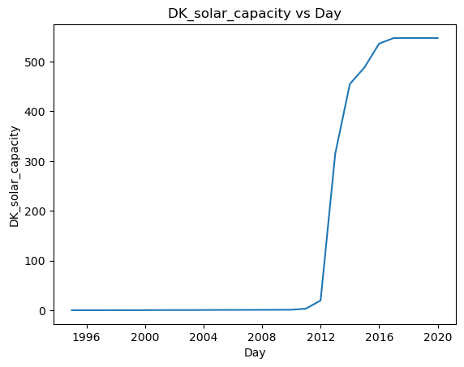

```python
# Plot Chart of DK_solar_capacity

plt.plot(DK_Sol['day'], DK_Sol['DK_solar_capacity'])

# Add axis labels and a title
plt.xlabel('Day')
plt.ylabel('DK_solar_capacity')
plt.title('DK_solar_capacity vs Day')

# Show the plot
plt.show()

# This Plot Chart shows there is a significent increase of DK Solar Capacity started from 2012, more Solar stations were installed from 2012.
# The Solar Capacity reach the peak of Capacity at 550 in 2016, the increasement stopped since then.
```